# 20 Years of Video Games 1996-2016

Enlik Tjioe

27 January 2019

## 1. Library

```r
library(ggplot2)
```

## 2. Kaggle Dataset

[20 Years of Games](https://www.kaggle.com/egrinstein/20-years-of-games)

## 3. Background

In this data analysis, I will focusing to three big names in console game industry. They are Nintendo, Sony, and Microsoft. I will try to visualize who exactly win the **Console Wars** during 20 years timeline between 1996-2016

## 4. Pre-processing

```r
ign <- read.csv("data_input/ign.csv", stringsAsFactors = FALSE)
#str(ign)

ign[, c("score_phrase", "platform", "genre", "editors_choice")] <- lapply(ign[, c("score_phrase", "platform", "genre", "editors_choice")] , as.factor)

ign20 <- ign[ign$release_year >= 1996 & ign$release_year <= 2016, ]

## save memory by removing unused data frame
rm(ign)
```

## 5. Data Preparation

I define new variables for only 3 big console game vendor: Nintendo, Sony, and Microsoft

```r
nintendo <- c("Game Boy","Game Boy Advance","Game Boy Color" ,"GameCube", "NES", "New Nintendo 3DS" ,"Nintendo 3DS","Nintendo 64", "Nintendo 64DD","Nintendo DS", "Nintendo DSi","Super NES","Wii","Wii U")

sony <- c("PlayStation","PlayStation 2","PlayStation 3","PlayStation 4" ,"PlayStation Portable","PlayStation Vita")

microsoft <- c("Xbox","Xbox 360","Xbox One")

# Function to create new console platform
consolePlatform <- function(x) {
  if (x %in% nintendo == TRUE){
    return("Nintendo")
  }

  else if(x %in% sony == TRUE){
    return("Sony")
  }

  else if(x %in% microsoft == TRUE){
    return("Microsoft")
  }

  else{
    return("Others")
  }

}

ign20$consolePlatform <- sapply(ign20$platform, consolePlatform)
table(ign20$consolePlatform)
```

```
##
## Microsoft  Nintendo    Others      Sony
##      2659      4907      5999      5059
```

Sony won total released game on their platform with total 5059 Nintendo in 2nd position with 4907 total games and Microsoft in 3rd position with 2659 total games

## 6. Data Visualization

### 6.1 Nintendo 1996-2016

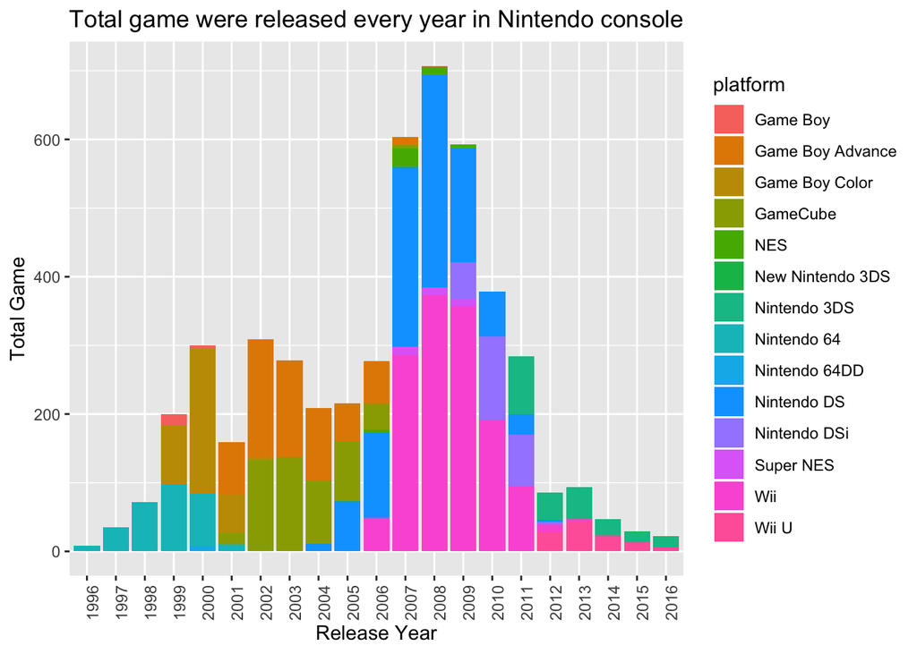

```r
ggplot(ign20[ign20$consolePlatform=="Nintendo",],aes(x=factor(release_year))) +
  geom_bar(aes(fill=platform)) +
  theme(axis.text.x = element_text(angle=90, hjust=1)) +
  labs(title = "Total game were released every year in Nintendo console", x = "Release Year", y = "Total Game")
```

```r
summary(ign20[ign20$consolePlatform=="Nintendo",])
```

```
##        X           score_phrase     title               url
##  Min.   :   33   Good    :1165   Length:4907        Length:4907
##  1st Qu.: 4802   Great   :1037   Class :character   Class :character
##  Median : 9777   Okay    : 815   Mode  :character   Mode  :character
##  Mean   : 9193   Mediocre: 661
##  3rd Qu.:13066   Bad     : 463
##  Max.   :18620   Amazing : 337
##                  (Other) : 429
##              platform        score               genre      editors_choice
##  Wii             :1366   Min.   : 0.800   Action    :1094   N:4234
##  Nintendo DS     :1045   1st Qu.: 5.300   Sports    : 485   Y: 673
##  Game Boy Advance: 623   Median : 7.000   Platformer: 348
##  GameCube        : 509   Mean   : 6.548   Adventure : 299
##  Game Boy Color  : 356   3rd Qu.: 8.000   Racing    : 296
##  Nintendo 64     : 302   Max.   :10.000   Puzzle    : 259
##  (Other)         : 706                    (Other)   :2126
##   release_year  release_month     release_day    consolePlatform
##  Min.   :1996   Min.   : 1.000   Min.   : 1.00   Length:4907
##  1st Qu.:2003   1st Qu.: 4.000   1st Qu.: 8.00   Class :character
##  Median :2007   Median : 8.000   Median :15.00   Mode  :character
##  Mean   :2006   Mean   : 7.251   Mean   :15.35
##  3rd Qu.:2009   3rd Qu.:11.000   3rd Qu.:22.50
##  Max.   :2016   Max.   :12.000   Max.   :31.00
##
```

Nintendo was the most senior game company compare to Sony and Microsoft. Nintendo has the worst year during 1996-1998, because Sony almost take down all the console game marketshare with their premiere platform. With the release of Wii, Nintendo is rising again with their most innovative game console Unfortunately, the Wii successor, Wii U, didn’t work well as its predecessor, and make Nintendo has the worst year again during 2014-2016.

### 6.2 Sony 1996-2016

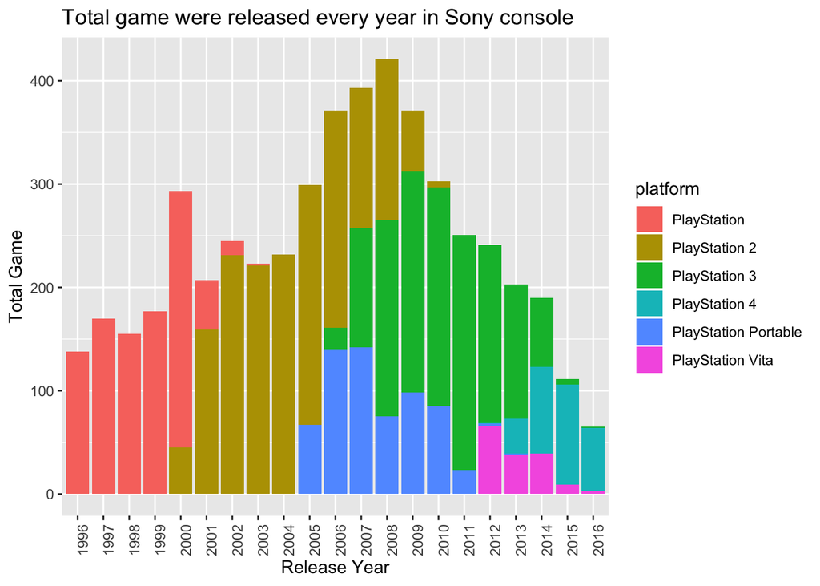

```r
ggplot(ign20[ign20$consolePlatform=="Sony",],aes(x=factor(release_year))) +
  geom_bar(aes(fill=platform)) +
  theme(axis.text.x = element_text(angle=90, hjust=1)) +
  labs(title = "Total game were released every year in Sony console", x = "Release Year", y = "Total Game")
```

```r
summary(ign20[ign20$consolePlatform=="Sony",])
```

```
##        X           score_phrase     title               url
##  Min.   :    0   Good    :1276   Length:5059        Length:5059
##  1st Qu.: 3656   Great   :1241   Class :character   Class :character
##  Median : 8481   Okay    : 808   Mode  :character   Mode  :character
##  Mean   : 8850   Amazing : 532
##  3rd Qu.:13940   Mediocre: 520
##  Max.   :18622   Bad     : 363
##                  (Other) : 319
##                  platform        score              genre
##  PlayStation 2       :1686   Min.   : 1.000   Action   :1030
##  PlayStation 3       :1356   1st Qu.: 6.000   Sports   : 702
##  PlayStation         : 952   Median : 7.300   Racing   : 414
##  PlayStation Portable: 633   Mean   : 6.945   Shooter  : 405
##  PlayStation 4       : 277   3rd Qu.: 8.200   RPG      : 286
##  PlayStation Vita    : 155   Max.   :10.000   Adventure: 268
##  (Other)             :   0                    (Other)  :1954
##  editors_choice  release_year  release_month     release_day
##  N:4105         Min.   :1996   Min.   : 1.000   Min.   : 1.00
##  Y: 954         1st Qu.:2002   1st Qu.: 4.000   1st Qu.: 8.00
##                 Median :2007   Median : 8.000   Median :16.00
##                 Mean   :2006   Mean   : 7.287   Mean   :15.86
##                 3rd Qu.:2010   3rd Qu.:10.000   3rd Qu.:23.00
##                 Max.   :2016   Max.   :12.000   Max.   :31.00
##
##  consolePlatform
##  Length:5059
##  Class :character
##  Mode  :character
##
##
##
##
```

Sony has been active in console game industry since 1996 with the release of phenomenal PlayStation 1. Until 2016, PlaySation 2 still the most popular console game for game release.

## 6.3 Microsoft 1996-2016

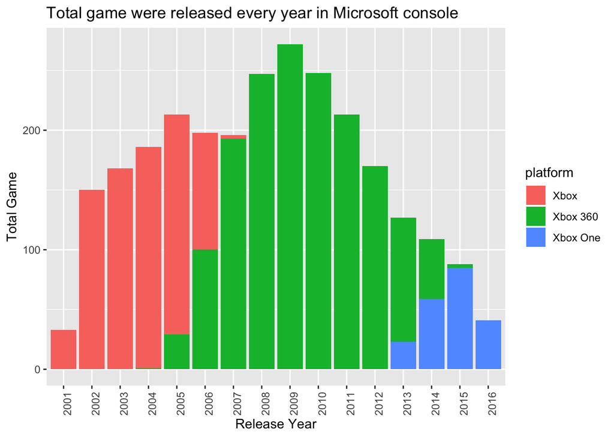

```r
ggplot(ign20[ign20$consolePlatform=="Microsoft",],aes(x=factor(release_year))) +
  geom_bar(aes(fill=platform)) +
  theme(axis.text.x = element_text(angle=90, hjust=1)) +
  labs(title = "Total game were released every year in Microsoft console", x = "Release Year", y = "Total Game")
```

```r
summary(ign20[ign20$consolePlatform=="Microsoft",])
```

```
##        X           score_phrase    title               url
##  Min.   :    3   Great   :772   Length:2659        Length:2659
##  1st Qu.: 6804   Good    :604   Class :character   Class :character
##  Median :11283   Okay    :413   Mode  :character   Mode  :character
##  Mean   :10998   Amazing :323
##  3rd Qu.:15418   Mediocre:253
##  Max.   :18623   Bad     :169
##                  (Other) :125
##        platform        score                      genre     editors_choice
##  Xbox 360  :1630   Min.   : 1.000   Action           :556   N:2038
##  Xbox      : 821   1st Qu.: 6.200   Shooter          :380   Y: 621
##  Xbox One  : 208   Median : 7.500   Sports           :331
##  Android   :   0   Mean   : 7.179   Racing           :177
##  Arcade    :   0   3rd Qu.: 8.500   Action, Adventure:157
##  Atari 2600:   0   Max.   :10.000   Adventure        :117
##  (Other)   :   0                    (Other)          :941
##   release_year  release_month     release_day    consolePlatform
##  Min.   :2001   Min.   : 1.000   Min.   : 1.00   Length:2659
##  1st Qu.:2005   1st Qu.: 4.000   1st Qu.: 8.00   Class :character
##  Median :2008   Median : 8.000   Median :16.00   Mode  :character
##  Mean   :2008   Mean   : 7.218   Mean   :15.75
##  3rd Qu.:2011   3rd Qu.:10.000   3rd Qu.:23.00
##  Max.   :2016   Max.   :12.000   Max.   :31.00
##
```

We can see that Microsoft doesn’t have any game released before 2001, that was because the first Microsoft game console, Xbox, was release on 2001. That means Bill Gates own-company doesn’t compete with Nintendo and Sony before that time.

Xbox 360 was the most popular Microsoft game platform

## 6.4 Console Wars

What is the most popular console during 1996-2016

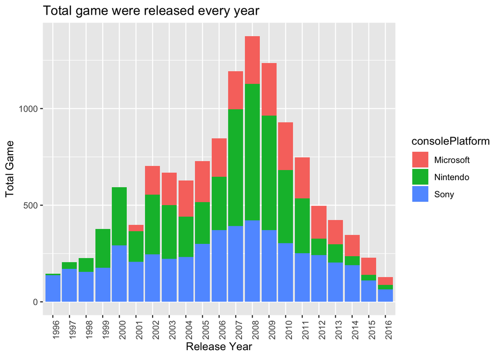

```r
ggplot(ign20[ign20$consolePlatform != "Others",],aes(x=factor(release_year))) +
  geom_bar(aes(fill=consolePlatform)) +
  theme(axis.text.x = element_text(angle=90, hjust=1)) +
  labs(title = "Total game were released every year", x = "Release Year", y = "Total Game")
```

## 7. Final Thoughts

Sony wins the 20-years **Console Wars** based on their consistency in game release every year, with more than 5000 game title released on their platform from 1996-2016.

## 8. What do I learn?

- Pre-processing data by subsetting date based on **release_year** column from ign dataframe
- Data preparation by creating new variable **consolePlatform** using 3 big console game vendor: Nintendo, Sony, and Microsoft
- Data visualization with ggplot2 using `geom_bar()` + `theme()` + `labs()`
- Analyze 20 years **Console Wars** with timeframe 1996-2016

## References

[kaggle.com](https://www.kaggle.com/jonathanbouchet/ign-data-20-years-of-vg)